# Section 1: Setup and Data Loading

```python
import numpy as np
import pandas as pd
import statsmodels.api as sm
import matplotlib.pyplot as plt
from itertools import combinations
from sklearn.preprocessing import OneHotEncoder, StandardScaler
from sklearn.compose import ColumnTransformer
from sklearn.pipeline import Pipeline
from sklearn.model_selection import train_test_split
from sklearn.linear_model import LinearRegression
from sklearn.metrics import mean_squared_error, r2_score
from scipy import stats
```

```python
path = 'data_clean.csv'
df_original = pd.read_csv(path)
```

```python
col_to_remove = ['Trip_Distance_km_log', 'Trip_Price_log']

df_original = df_original.drop(col_to_remove, axis =1)

df_original.info()
```

```
<class 'pandas.core.frame.DataFrame'>
RangeIndex: 891 entries, 0 to 890
Data columns (total 11 columns):
 #   Column                 Non-Null Count  Dtype
---  ------                 --------------  -----
 0   Trip_Distance_km       891 non-null    float64
 1   Time_of_Day            891 non-null    object
 2   Day_of_Week            891 non-null    object
 3   Passenger_Count        891 non-null    float64
 4   Traffic_Conditions     891 non-null    object
 5   Weather                891 non-null    object
 6   Base_Fare              891 non-null    float64
 7   Per_Km_Rate            891 non-null    float64
 8   Per_Minute_Rate        891 non-null    float64
 9   Trip_Duration_Minutes  891 non-null    float64
 10  Trip_Price             891 non-null    float64
dtypes: float64(7), object(4)
memory usage: 76.7+ KB
```

# Section 2: Feature Engineering (One-Hot Encoding)

```python
# Create dummy variables for categorical columns
categorical_columns = ['Time_of_Day', 'Day_of_Week', 'Traffic_Conditions', 'Weather']

df_linear_model = df_original.copy()

# Create dummies and drop first category for each variable
for column in categorical_columns:
    dummies = pd.get_dummies(df_linear_model[column], prefix=column, drop_first=True)
    df_linear_model = pd.concat([df_linear_model, dummies], axis=1)
    df_linear_model = df_linear_model.drop(column, axis=1)

df_linear_model.info()
```

```
<class 'pandas.core.frame.DataFrame'>
RangeIndex: 891 entries, 0 to 890
Data columns (total 15 columns):
 #   Column                     Non-Null Count  Dtype
---  ------                     --------------  -----
 0   Trip_Distance_km           891 non-null    float64
 1   Passenger_Count            891 non-null    float64
 2   Base_Fare                  891 non-null    float64
 3   Per_Km_Rate                891 non-null    float64
 4   Per_Minute_Rate            891 non-null    float64
 5   Trip_Duration_Minutes      891 non-null    float64
 6   Trip_Price                 891 non-null    float64
 7   Time_of_Day_Evening        891 non-null    bool
 8   Time_of_Day_Morning        891 non-null    bool
 9   Time_of_Day_Night          891 non-null    bool
 10  Day_of_Week_Weekend        891 non-null    bool
 11  Traffic_Conditions_Low     891 non-null    bool
 12  Traffic_Conditions_Medium  891 non-null    bool
 13  Weather_Rain               891 non-null    bool
 14  Weather_Snow               891 non-null    bool
dtypes: bool(8), float64(7)
memory usage: 55.8 KB
```

```python
df_linear_model.head()
```

|  | Trip_Distance_km | Passenger_Count | Base_Fare | Per_Km_Rate | Per_Minute_Rate | Trip_Duration_Minutes | Trip_Price | Time_of_Day_Evening | Time_of_Day_Morning | Time_of_Day_Night | Day_of_Week_Weekend | Traffic_Conditions_Low | Traffic_Conditions_Medium | Weather_Rain | Weather_Snow |
| --- | --- | --- | --- | --- | --- | --- | --- | --- | --- | --- | --- | --- | --- | --- | --- |
| 0 | 19.35 | 3.0 | 3.56 | 0.80 | 0.32 | 53.82 | 36.2624 | False | True | False | False | True | False | False | False |
| 1 | 36.87 | 1.0 | 2.70 | 1.21 | 0.15 | 37.27 | 52.9032 | True | False | False | True | False | False | False | False |
| 2 | 30.33 | 4.0 | 3.48 | 0.51 | 0.15 | 116.81 | 36.4698 | True | False | False | False | True | False | False | False |
| 3 | 8.64 | 2.0 | 2.55 | 1.71 | 0.48 | 89.33 | 60.2028 | False | False | False | True | False | True | False | False |
| 4 | 3.85 | 4.0 | 3.51 | 1.66 | 0.27 | 5.05 | 11.2645 | False | False | False | False | False | False | True | False |

# Section 3: Data Scaling and Preparation for `statsmodels` OLS

```python
#set the scaler
numerical_columns = ['Trip_Distance_km', 'Passenger_Count', 'Base_Fare',
                    'Per_Km_Rate', 'Per_Minute_Rate', 'Trip_Duration_Minutes', 'Trip_Price']

target = ['Trip_Price']

scaler = StandardScaler()
df_model_scaled = df_linear_model.copy()
df_model_scaled[numerical_columns] = scaler.fit_transform(df_linear_model[numerical_columns])

X = df_model_scaled.drop('Trip_Price', axis=1)
y = df_model_scaled['Trip_Price']

# Transform booleans in integer for better handling
bool_columns = X.select_dtypes(include='bool').columns
X[bool_columns] = X[bool_columns].astype(int)

# Split dataset into training and test (80% training, 20% test)
X_train, X_test, y_train, y_test = train_test_split(X, y, test_size=0.2, random_state=42)
```

# Section 4: Linear Regression with `statsmodels.api.OLS` (Initial Model)

```python
# Add constant for statsmodels
X_train_sm = sm.add_constant(X_train)

# Fit the model
linear_model = sm.OLS(y_train, X_train_sm).fit()

# Print summary
print("\nModel Summary:")
print(linear_model.summary())
```

```
Model Summary:
                            OLS Regression Results
==============================================================================
Dep. Variable:             Trip_Price   R-squared:                       0.911
Model:                            OLS   Adj. R-squared:                  0.909
Method:                 Least Squares   F-statistic:                     510.8
Date:                Wed, 21 May 2025   Prob (F-statistic):               0.00
Time:                        01:28:58   Log-Likelihood:                -145.57
No. Observations:                 712   AIC:                             321.1
Df Residuals:                     697   BIC:                             389.7
Df Model:                          14
Covariance Type:            nonrobust
=============================================================================================
                                coef    std err          t      P>|t|      [0.025      0.975]
---------------------------------------------------------------------------------------------
const                        -0.0355      0.031     -1.128      0.260      -0.097       0.026
Trip_Distance_km              0.8023      0.012     69.568      0.000       0.780       0.825
Passenger_Count               0.0064      0.011      0.566      0.571      -0.016       0.028
Base_Fare                     0.0195      0.011      1.714      0.087      -0.003       0.042
Per_Km_Rate                   0.3611      0.011     31.510      0.000       0.339       0.384
Per_Minute_Rate               0.2566      0.011     22.996      0.000       0.235       0.279
Trip_Duration_Minutes         0.2790      0.011     24.473      0.000       0.257       0.301
Time_of_Day_Evening           0.0370      0.030      1.224      0.221      -0.022       0.096
Time_of_Day_Morning           0.0353      0.028      1.275      0.203      -0.019       0.090
Time_of_Day_Night            -0.0076      0.041     -0.186      0.852      -0.087       0.072
Day_of_Week_Weekend           0.0054      0.024      0.220      0.826      -0.042       0.053
Traffic_Conditions_Low        0.0162      0.032      0.512      0.609      -0.046       0.078
Traffic_Conditions_Medium     0.0040      0.032      0.125      0.901      -0.059       0.067
Weather_Rain                  0.0157      0.026      0.596      0.551      -0.036       0.068
Weather_Snow                  0.0147      0.049      0.302      0.763      -0.081       0.110
==============================================================================
Omnibus:                      162.209   Durbin-Watson:                   2.006
Prob(Omnibus):                  0.000   Jarque-Bera (JB):             5614.814
Skew:                          -0.086   Prob(JB):                         0.00
Kurtosis:                      16.756   Cond. No.                         5.88
==============================================================================

Notes:
[1] Standard Errors assume that the covariance matrix of the errors is correctly specified.
```

This requires inverse transforming the scaled target and predictions.

Assuming 'Trip_Price' was log-transformed before scaling, we would use np.exp().

If 'Trip_Price' was directly scaled, then np.exp() might not be appropriate here.

The original notebook indicates 'Trip_Price_log' was removed, suggesting 'Trip_Price' itself might not be log-transformed in df_original for this specific model, but the MAPE calculation uses np.exp, implying a log-transformation might have been implicitly assumed or applied earlier in the overall project context.

For consistency with the provided code, np.exp is kept.

```python
# Add constant for prediction
X_test_sm = sm.add_constant(X_test)

# Make predictions
y_pred = linear_model.predict(X_test_sm)

# Calculate metrics
mse = np.mean((y_test - y_pred) ** 2)
rmse = np.sqrt(mse)
r2 = linear_model.rsquared

# Calculate metrics on actual price scale
actual_prices = np.exp(y_test)
predicted_prices = np.exp(y_pred)
mape = np.mean(np.abs((actual_prices - predicted_prices) / actual_prices)) * 100

print("\nModel Performance Metrics:")
print(f"Mean Squared Error: {mse:.4f}")
#print(f"Root Mean Squared Error: {rmse:.4f}")
print(f"R-squared: {r2:.4f}")
#print(f"Mean Absolute Percentage Error: {mape:.2f}%")
```

```
Model Performance Metrics:
Mean Squared Error: 0.1056
R-squared: 0.9112
```

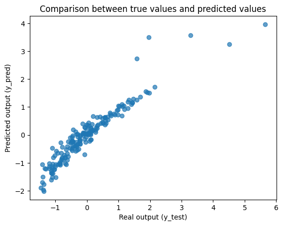

```python
plt.scatter(y_test, y_pred, alpha=0.7)
plt.xlabel('Real output (y_test)')
plt.ylabel('Predicted output (y_pred)')
plt.title('Comparison between true values and predicted values')
plt.show()
```

# Section 5: Model Diagnostics and Outlier Detection

```python
# compute influence of each observation
influence = linear_model.get_influence()

# standardized residuals
standardized_residuals = influence.resid_studentized_internal

# Leverage (hat values)
leverage = influence.hat_matrix_diag

# Cook's Distance
cooks_distance = influence.cooks_distance[0]

# DFFITS
dffits = influence.dffits[0]

# DataFrame which contains the diagnostic measures
diagnostics = pd.DataFrame({
    'Standardized_Residuals': standardized_residuals,
    'Leverage': leverage,
    'Cooks_Distance': cooks_distance,
    'DFFITS': dffits
})

# Plot the diagnostics
print(diagnostics.head())
```

```
   Standardized_Residuals  Leverage  Cooks_Distance    DFFITS
0                0.542550  0.015766        0.000314  0.068632
1               -0.062645  0.018243        0.000005 -0.008533
2                0.778866  0.019259        0.000794  0.109113
3                1.032624  0.022133        0.001609  0.155360
4                0.433212  0.018064        0.000230  0.058724
```

```python
# threshold
threshold_std_resid = 3
threshold_leverage = 2 * (X_train_sm.shape[1] + 1) / X_train_sm.shape[0]
threshold_cooks = 4 / X_train_sm.shape[0]
threshold_dffits = 2 * np.sqrt((X_train_sm.shape[1] + 1) / X_train_sm.shape[0])

# identify outliers
outliers = diagnostics[
    (diagnostics['Standardized_Residuals'].abs() > threshold_std_resid) |
    (diagnostics['Leverage'] > threshold_leverage) |
    (diagnostics['Cooks_Distance'] > threshold_cooks) |
    (diagnostics['DFFITS'].abs() > threshold_dffits)]
```

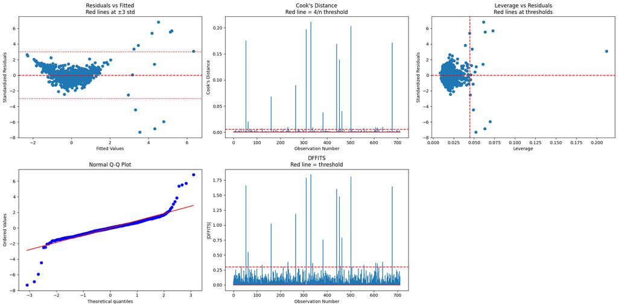

```python
# Create diagnostic plots
fig = plt.figure(figsize=(20, 10))

# 1. Standardized Residuals vs Fitted Values
plt.subplot(231)
plt.scatter(linear_model.fittedvalues, standardized_residuals)
plt.axhline(y=0, color='r', linestyle='--')
plt.axhline(y=3, color='r', linestyle=':')
plt.axhline(y=-3, color='r', linestyle=':')
plt.xlabel('Fitted Values')
plt.ylabel('Standardized Residuals')
plt.title('Residuals vs Fitted\nRed lines at ±3 std')

# 2. Cook's Distance Plot
plt.subplot(232)
plt.stem(range(len(cooks_distance)), cooks_distance, markerfmt=',')
plt.axhline(y=threshold_cooks, color='r', linestyle='--')
plt.xlabel('Observation Number')
plt.ylabel("Cook's Distance")
plt.title("Cook's Distance\nRed line = 4/n threshold")

# 3. Leverage vs Standardized Residuals
plt.subplot(233)
plt.scatter(leverage, standardized_residuals)
plt.axhline(y=0, color='r', linestyle='--')
plt.axvline(x=threshold_leverage, color='r', linestyle='--')
plt.xlabel('Leverage')
plt.ylabel('Standardized Residuals')
plt.title('Leverage vs Residuals\nRed lines at thresholds')

# 4. QQ Plot
plt.subplot(234)
stats.probplot(standardized_residuals, dist="norm", plot=plt)
plt.title('Normal Q-Q Plot')

# 5. DFFITS Plot
plt.subplot(235)
plt.stem(range(len(dffits)), np.abs(dffits), markerfmt=',')
plt.axhline(y=threshold_dffits, color='r', linestyle='--')
plt.xlabel('Observation Number')
plt.ylabel('|DFFITS|')
plt.title('DFFITS\nRed line = threshold')

plt.tight_layout()
plt.show()
```

**Observation about residuals:**

The presence of a clear pattern in the residuals suggests that the model might be missing key explanatory variables, or that transformations (such as polynomial terms or logarithmic transformation) might be necessary to better capture the relationship. The model likely needs refinement, such as including interaction terms, polynomial features, or transforming variables to better fit the data.

```python
# observations with high leverage
high_leverage_points = diagnostics[diagnostics['Leverage'] > (2 * X_train_sm.shape[1] / X_train_sm.shape[0])]

# observations with high Cook's Distance
high_cooks_distance_points = diagnostics[diagnostics['Cooks_Distance'] > 1]

# observations with high DFFITS
threshold_dffits = 2 * ((X_train_sm.shape[1] / X_train_sm.shape[0]) ** 0.5)
high_dffits_points = diagnostics[abs(diagnostics['DFFITS']) > threshold_dffits]

# Show influential points
print("Punti con alto leverage:\n", high_leverage_points)
```

```
Punti con alto leverage:
      Standardized_Residuals  Leverage  Cooks_Distance    DFFITS
53                -5.933027  0.069414        0.175047 -1.661743
63                -2.514492  0.045205        0.019957 -0.549233
68                -1.143929  0.048605        0.004457 -0.258615
82                -0.663026  0.043123        0.001321 -0.140696
161               -4.445296  0.049036        0.067929 -1.023311
168               -1.081023  0.043295        0.003526 -0.229994
186                0.963942  0.042422        0.002744  0.202878
231                0.053307  0.045976        0.000009  0.011694
266                5.378712  0.044516        0.089859  1.185003
278                1.245474  0.046736        0.005070  0.275885
296                1.106301  0.052488        0.004520  0.260423
311               -7.310962  0.052242        0.196417 -1.785041
330               -6.864191  0.062937        0.210974 -1.840970
339                1.430821  0.060937        0.008857  0.364760
347               -0.563984  0.045752        0.001017 -0.123432
355               -0.198529  0.043059        0.000118 -0.042084
382                3.374323  0.047390        0.037762  0.758297
441                3.070272  0.211955        0.169027  1.602021
452                5.538733  0.063560        0.138814  1.474769
502                6.821873  0.061549        0.203483  1.807189
627                0.095037  0.042769        0.000027  0.020074
631                0.404691  0.050938        0.000586  0.093700
678                5.714754  0.072827        0.171015  1.639352
706               -0.235943  0.042586        0.000165 -0.049728
```

```python
print("\nPunti con alta Cook's Distance:\n", high_cooks_distance_points)
```

```
Punti con alta Cook's Distance:
 Empty DataFrame
Columns: [Standardized_Residuals, Leverage, Cooks_Distance, DFFITS]
Index: []
```

```python
print("\nPunti con alto DFFITS:\n", high_dffits_points)
```

```
Punti con alto DFFITS:
      Standardized_Residuals  Leverage  Cooks_Distance    DFFITS
33                 2.028752  0.022755        0.006389  0.310272
53                -5.933027  0.069414        0.175047 -1.661743
63                -2.514492  0.045205        0.019957 -0.549233
122               -2.074266  0.024660        0.007252 -0.330612
161               -4.445296  0.049036        0.067929 -1.023311
213                1.961650  0.022476        0.005899  0.298062
232                2.475689  0.023176        0.009694  0.382744
266                5.378712  0.044516        0.089859  1.185003
311               -7.310962  0.052242        0.196417 -1.785041
330               -6.864191  0.062937        0.210974 -1.840970
339                1.430821  0.060937        0.008857  0.364760
382                3.374323  0.047390        0.037762  0.758297
441                3.070272  0.211955        0.169027  1.602021
452                5.538733  0.063560        0.138814  1.474769
458                2.245833  0.019283        0.006611  0.315831
463                3.850374  0.039167        0.040289  0.785231
502                6.821873  0.061549        0.203483  1.807189
505                1.427934  0.041976        0.005956  0.299120
557                1.612233  0.039962        0.007213  0.329313
607               -2.023357  0.021176        0.005905 -0.298267
608                2.097565  0.029581        0.008941  0.367121
614               -2.450954  0.020881        0.008541 -0.359216
621                1.830674  0.025515        0.005850  0.296727
637                2.645155  0.020184        0.009609  0.381293
678                5.714754  0.072827        0.171015  1.639352
```

```python
# Delete outliers from the training set
print(len(outliers))
print(outliers.index)
```

```
31
Index([ 33,  53,  63,  68, 122, 161, 213, 231, 232, 266, 278, 296, 311, 330,
       339, 347, 382, 441, 452, 458, 463, 502, 505, 557, 607, 608, 614, 621,
       631, 637, 678],
      dtype='int64')
```

# Section 6: Model Retraining After Outlier Removal

```python
# Remove outliers from the original dataset or from its copy
df_model_cleaned = df_model_scaled.drop(index=outliers.index)
df_model_cleaned.info()
```

```
<class 'pandas.core.frame.DataFrame'>
Index: 860 entries, 0 to 890
Data columns (total 15 columns):
 #   Column                     Non-Null Count  Dtype
---  ------                     --------------  -----
 0   Trip_Distance_km           860 non-null    float64
 1   Passenger_Count            860 non-null    float64
 2   Base_Fare                  860 non-null    float64
 3   Per_Km_Rate                860 non-null    float64
 4   Per_Minute_Rate            860 non-null    float64
 5   Trip_Duration_Minutes      860 non-null    float64
 6   Trip_Price                 860 non-null    float64
 7   Time_of_Day_Evening        860 non-null    bool
 8   Time_of_Day_Morning        860 non-null    bool
 9   Time_of_Day_Night          860 non-null    bool
 10  Day_of_Week_Weekend        860 non-null    bool
 11  Traffic_Conditions_Low     860 non-null    bool
 12  Traffic_Conditions_Medium  860 non-null    bool
 13  Weather_Rain               860 non-null    bool
 14  Weather_Snow               860 non-null    bool
dtypes: bool(8), float64(7)
memory usage: 60.5 KB
```

```python
X = df_model_cleaned.drop('Trip_Price', axis=1)
y = df_model_cleaned['Trip_Price']

# Transform booleans in integer for better handling
bool_columns = X.select_dtypes(include='bool').columns
X[bool_columns] = X[bool_columns].astype(int)

# Split dataset into training and test (80% training, 20% test)
X_train, X_test, y_train, y_test = train_test_split(X, y, test_size=0.2, random_state=42)

# Add constant for statsmodels
X_train_sm = sm.add_constant(X_train)

# Fit the model
linear_model = sm.OLS(y_train, X_train_sm).fit()

# Print summary
print("\nModel Summary:")
print(linear_model.summary())
```

```
Model Summary:
                            OLS Regression Results
==============================================================================
Dep. Variable:             Trip_Price   R-squared:                       0.911
Model:                            OLS   Adj. R-squared:                  0.910
Method:                 Least Squares   F-statistic:                     494.4
Date:                Wed, 21 May 2025   Prob (F-statistic):               0.00
Time:                        01:28:59   Log-Likelihood:                -142.60
No. Observations:                 688   AIC:                             315.2
Df Residuals:                     673   BIC:                             383.2
Df Model:                          14
Covariance Type:            nonrobust
=============================================================================================
                                coef    std err          t      P>|t|      [0.025      0.975]
---------------------------------------------------------------------------------------------
const                        -0.0313      0.032     -0.981      0.327      -0.094       0.031
Trip_Distance_km              0.7978      0.012     67.566      0.000       0.775       0.821
Passenger_Count               0.0043      0.011      0.380      0.704      -0.018       0.027
Base_Fare                     0.0145      0.011      1.266      0.206      -0.008       0.037
Per_Km_Rate                   0.3569      0.012     30.908      0.000       0.334       0.380
Per_Minute_Rate               0.2631      0.011     23.124      0.000       0.241       0.285
Trip_Duration_Minutes         0.2750      0.011     23.960      0.000       0.252       0.298
Time_of_Day_Evening           0.0359      0.031      1.161      0.246      -0.025       0.097
Time_of_Day_Morning           0.0324      0.028      1.142      0.254      -0.023       0.088
Time_of_Day_Night            -0.0220      0.041     -0.539      0.590      -0.102       0.058
Day_of_Week_Weekend           0.0047      0.025      0.187      0.851      -0.045       0.054
Traffic_Conditions_Low        0.0207      0.032      0.650      0.516      -0.042       0.083
Traffic_Conditions_Medium    -0.0146      0.032     -0.452      0.652      -0.078       0.049
Weather_Rain                  0.0031      0.027      0.113      0.910      -0.050       0.056
Weather_Snow                  0.0685      0.047      1.452      0.147      -0.024       0.161
==============================================================================
Omnibus:                      157.028   Durbin-Watson:                   2.073
Prob(Omnibus):                  0.000   Jarque-Bera (JB):             4936.584
Skew:                          -0.193   Prob(JB):                         0.00
Kurtosis:                      16.117   Cond. No.                         5.83
==============================================================================

Notes:
[1] Standard Errors assume that the covariance matrix of the errors is correctly specified.
```

```python
# Add constant for prediction
X_test_sm = sm.add_constant(X_test)

# Make predictions
y_pred = linear_model.predict(X_test_sm)

# Calculate metrics
mse = np.mean((y_test - y_pred) ** 2)
rmse = np.sqrt(mse)
r2 = linear_model.rsquared

# Calculate metrics on actual price scale
actual_prices = np.exp(y_test)
predicted_prices = np.exp(y_pred)
mape = np.mean(np.abs((actual_prices - predicted_prices) / actual_prices)) * 100

print("\nModel Performance Metrics:")
print(f"Mean Squared Error: {mse:.4f}")
print(f"R-squared: {r2:.4f}")
```

```
Model Performance Metrics:
Mean Squared Error: 0.0824
R-squared: 0.9114
```

```python
# Get residuals and fitted values
residuals = linear_model.resid
fitted_values = linear_model.fittedvalues
```

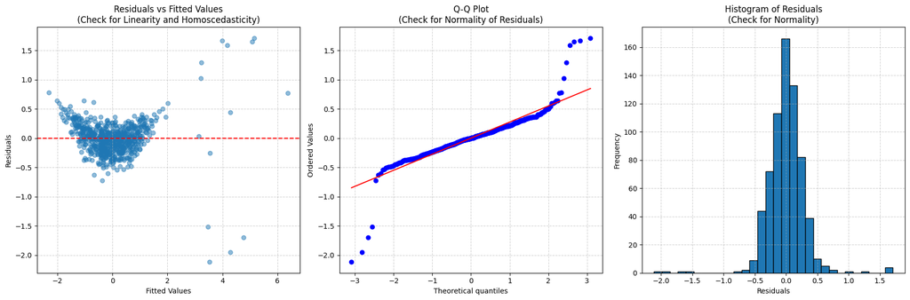

```python
# Create diagnostic plots for the refitted model
plt.figure(figsize=(18, 6)) # Adjusted figure size

# 1. Residuals vs Fitted Values Plot
plt.subplot(1, 3, 1) # 1 row, 3 columns, 1st plot
plt.scatter(fitted_values, residuals, alpha=0.5)
plt.axhline(y=0, color='r', linestyle='--')
plt.xlabel('Fitted Values')
plt.ylabel('Residuals')
plt.title('Residuals vs Fitted Values\n(Check for Linearity and Homoscedasticity)')
plt.grid(True, linestyle='--', alpha=0.6)

# 2. Q-Q Plot for Normality of Residuals
plt.subplot(1, 3, 2) # 1 row, 3 columns, 2nd plot
stats.probplot(residuals, dist="norm", plot=plt)
plt.title('Q-Q Plot\n(Check for Normality of Residuals)')
plt.grid(True, linestyle='--', alpha=0.6)

# 3. Residuals Histogram
plt.subplot(1, 3, 3) # 1 row, 3 columns, 3rd plot
plt.hist(residuals, bins=30, edgecolor='black')
plt.xlabel('Residuals')
plt.ylabel('Frequency')
plt.title('Histogram of Residuals\n(Check for Normality)')
plt.grid(True, linestyle='--', alpha=0.6)

plt.tight_layout()
plt.show()
```

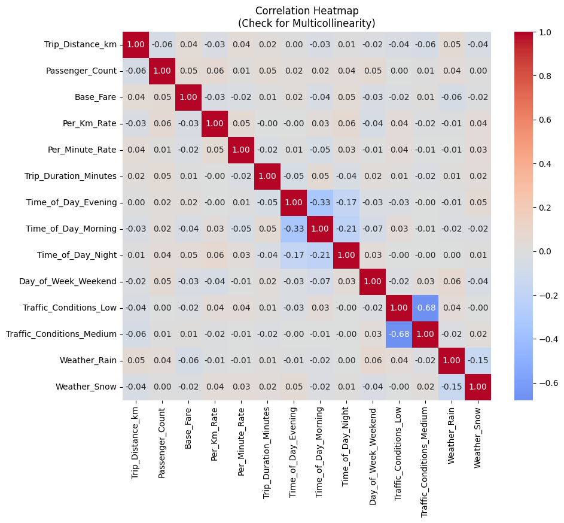

```python
# 4. Correlation Heatmap
import seaborn as sns
correlation_matrix = X_train.corr()
plt.figure(figsize=(10, 8))
sns.heatmap(correlation_matrix, cmap='coolwarm', center=0, annot=True, fmt='.2f', square=True)
plt.title('Correlation Heatmap\n(Check for Multicollinearity)')
```

# Section 7: Best Subset Selection

```python
df_model_scaled.info()
```

```
<class 'pandas.core.frame.DataFrame'>
RangeIndex: 891 entries, 0 to 890
Data columns (total 15 columns):
 #   Column                     Non-Null Count  Dtype
---  ------                     --------------  -----
 0   Trip_Distance_km           891 non-null    float64
 1   Passenger_Count            891 non-null    float64
 2   Base_Fare                  891 non-null    float64
 3   Per_Km_Rate                891 non-null    float64
 4   Per_Minute_Rate            891 non-null    float64
 5   Trip_Duration_Minutes      891 non-null    float64
 6   Trip_Price                 891 non-null    float64
 7   Time_of_Day_Evening        891 non-null    bool
 8   Time_of_Day_Morning        891 non-null    bool
 9   Time_of_Day_Night          891 non-null    bool
 10  Day_of_Week_Weekend        891 non-null    bool
 11  Traffic_Conditions_Low     891 non-null    bool
 12  Traffic_Conditions_Medium  891 non-null    bool
 13  Weather_Rain               891 non-null    bool
 14  Weather_Snow               891 non-null    bool
dtypes: bool(8), float64(7)
memory usage: 55.8 KB
```

```python
X = df_model_scaled.drop('Trip_Price', axis=1)
y = df_model_scaled['Trip_Price']

# Transform booleans in integer for better handling
bool_columns = X.select_dtypes(include='bool').columns
X[bool_columns] = X[bool_columns].astype(int)

# Split dataset into training and test (80% training, 20% test)
X_train, X_test, y_train, y_test = train_test_split(X, y, test_size=0.2, random_state=42)

# Assicurati che X_train_sm e y_train abbiano gli stessi indici
X_train = X_train.loc[y_train.index]

n_features = X_train.shape[1]
best_models = {}

for k in range(1, n_features + 1):
    best_score = -np.inf
    best_combo = None
    best_model = None

    # Get all possible combinations of k features
    for combo in combinations(range(n_features), k):
        # Get the features for this combination
        X_subset = X_train.iloc[:, list(combo)]

        # Add constant
        X_subset = sm.add_constant(X_subset)

        # Assicurati che gli indici siano allineati
        X_subset = X_subset.loc[y_train.index]

        # Fit model
        model = sm.OLS(y_train, X_subset).fit()

        # Calculate adjusted R-squared
        score = model.rsquared_adj

        if score > best_score:
            best_score = score
            best_combo = combo
            best_model = model

    # Store best model for this number of features
    best_models[k] = {
        'features': [X_train_sm.columns[i] for i in best_combo],
        'model': best_model,
        'adj_r2': best_score,
        'aic': best_model.aic,
        'bic': best_model.bic
    }

    print(f"\nBest model with {k} features:")
    print(f"Features: {best_models[k]['features']}")
    print(f"Adjusted R-squared: {best_score:.4f}")
    print(f"AIC: {best_model.aic:.4f}")
    print(f"BIC: {best_model.bic:.4f}")
```

```
Best model with 1 features:
Features: ['const']
Adjusted R-squared: 0.6209
AIC: 1327.4854
BIC: 1336.6215

Best model with 2 features:
Features: ['const', 'Base_Fare']
Adjusted R-squared: 0.7655
AIC: 986.4694
BIC: 1000.1736

Best model with 3 features:
Features: ['const', 'Base_Fare', 'Per_Minute_Rate']
Adjusted R-squared: 0.8422
AIC: 705.5182
BIC: 723.7905

Best model with 4 features:
Features: ['const', 'Base_Fare', 'Per_Km_Rate', 'Per_Minute_Rate']
Adjusted R-squared: 0.9099
AIC: 307.7991
BIC: 330.6395

Best model with 5 features:
Features: ['const', 'Passenger_Count', 'Base_Fare', 'Per_Km_Rate', 'Per_Minute_Rate']
Adjusted R-squared: 0.9101
AIC: 307.0633
BIC: 334.4718

Best model with 6 features:
Features: ['const', 'Passenger_Count', 'Base_Fare', 'Per_Km_Rate', 'Per_Minute_Rate', 'Time_of_Day_Evening']
Adjusted R-squared: 0.9101
AIC: 308.0865
BIC: 340.0630

Best model with 7 features:
Features: ['const', 'Passenger_Count', 'Base_Fare', 'Per_Km_Rate', 'Per_Minute_Rate', 'Trip_Duration_Minutes', 'Time_of_Day_Evening']
Adjusted R-squared: 0.9102
AIC: 308.3595
```

[output cut: 28 more lines]

```
Adjusted R-squared: 0.9097
AIC: 317.1833
BIC: 376.5683

Best model with 13 features:
Features: ['const', 'Trip_Distance_km', 'Passenger_Count', 'Base_Fare', 'Per_Km_Rate', 'Per_Minute_Rate', 'Trip_Duration_Minutes', 'Time_of_Day_Evening', 'Time_of_Day_Morning', 'Time_of_Day_Night', 'Day_of_Week_Weekend', 'Traffic_Conditions_Medium', 'Weather_Rain']
Adjusted R-squared: 0.9095
AIC: 319.1479
BIC: 383.1010

Best model with 14 features:
Features: ['const', 'Trip_Distance_km', 'Passenger_Count', 'Base_Fare', 'Per_Km_Rate', 'Per_Minute_Rate', 'Trip_Duration_Minutes', 'Time_of_Day_Evening', 'Time_of_Day_Morning', 'Time_of_Day_Night', 'Day_of_Week_Weekend', 'Traffic_Conditions_Low', 'Traffic_Conditions_Medium', 'Weather_Rain']
Adjusted R-squared: 0.9094
AIC: 321.1320
BIC: 389.6532
```

```python
#X_train_sm.drop('const', axis=1)
X_train= X_train.loc[y_train.index]

n_features = X_train.shape[1]

best_models = {}

for k in range(1, n_features + 1):
    best_score = -np.inf
    best_combo = None
    best_model = None

    # Get all possible combinations of k features
    for combo in combinations(range(n_features), k):
        # Get the features for this combination
        X_subset = X_train.iloc[:, list(combo)]

        # Add constant
        X_subset = sm.add_constant(X_subset)

        # Fit model
        model = sm.OLS(y_train, X_subset).fit()

        # Calculate adjusted R-squared
        score = model.rsquared_adj

        if score > best_score:
            best_score = score
            best_combo = combo
            best_model = model

    # Store best model for this number of features
    best_models[k] = {
        'features': [X_train.columns[i] for i in best_combo],
        'model': best_model,
        'adj_r2': best_score,
        'aic': best_model.aic,
        'bic': best_model.bic
    }

    print(f"\nBest model with {k} features:")
    print(f"Features: {best_models[k]['features']}")
    print(f"Adjusted R-squared: {best_score:.4f}")
    print(f"AIC: {best_model.aic:.4f}")
    print(f"BIC: {best_model.bic:.4f}")
```

```
Best model with 1 features:
Features: ['Trip_Distance_km']
Adjusted R-squared: 0.6209
AIC: 1327.4854
BIC: 1336.6215

Best model with 2 features:
Features: ['Trip_Distance_km', 'Per_Km_Rate']
Adjusted R-squared: 0.7655
AIC: 986.4694
BIC: 1000.1736

Best model with 3 features:
Features: ['Trip_Distance_km', 'Per_Km_Rate', 'Trip_Duration_Minutes']
Adjusted R-squared: 0.8422
AIC: 705.5182
BIC: 723.7905

Best model with 4 features:
Features: ['Trip_Distance_km', 'Per_Km_Rate', 'Per_Minute_Rate', 'Trip_Duration_Minutes']
Adjusted R-squared: 0.9099
AIC: 307.7991
BIC: 330.6395

Best model with 5 features:
Features: ['Trip_Distance_km', 'Base_Fare', 'Per_Km_Rate', 'Per_Minute_Rate', 'Trip_Duration_Minutes']
Adjusted R-squared: 0.9101
AIC: 307.0633
BIC: 334.4718

Best model with 6 features:
Features: ['Trip_Distance_km', 'Base_Fare', 'Per_Km_Rate', 'Per_Minute_Rate', 'Trip_Duration_Minutes', 'Time_of_Day_Morning']
Adjusted R-squared: 0.9101
AIC: 308.0865
BIC: 340.0630

Best model with 7 features:
Features: ['Trip_Distance_km', 'Base_Fare', 'Per_Km_Rate', 'Per_Minute_Rate', 'Trip_Duration_Minutes', 'Time_of_Day_Evening', 'Time_of_Day_Morning']
Adjusted R-squared: 0.9102
AIC: 308.3595
```

[output cut: 28 more lines]

```
Adjusted R-squared: 0.9097
AIC: 317.1833
BIC: 376.5683

Best model with 13 features:
Features: ['Trip_Distance_km', 'Passenger_Count', 'Base_Fare', 'Per_Km_Rate', 'Per_Minute_Rate', 'Trip_Duration_Minutes', 'Time_of_Day_Evening', 'Time_of_Day_Morning', 'Time_of_Day_Night', 'Day_of_Week_Weekend', 'Traffic_Conditions_Low', 'Weather_Rain', 'Weather_Snow']
Adjusted R-squared: 0.9095
AIC: 319.1479
BIC: 383.1010

Best model with 14 features:
Features: ['Trip_Distance_km', 'Passenger_Count', 'Base_Fare', 'Per_Km_Rate', 'Per_Minute_Rate', 'Trip_Duration_Minutes', 'Time_of_Day_Evening', 'Time_of_Day_Morning', 'Time_of_Day_Night', 'Day_of_Week_Weekend', 'Traffic_Conditions_Low', 'Traffic_Conditions_Medium', 'Weather_Rain', 'Weather_Snow']
Adjusted R-squared: 0.9094
AIC: 321.1320
BIC: 389.6532
```

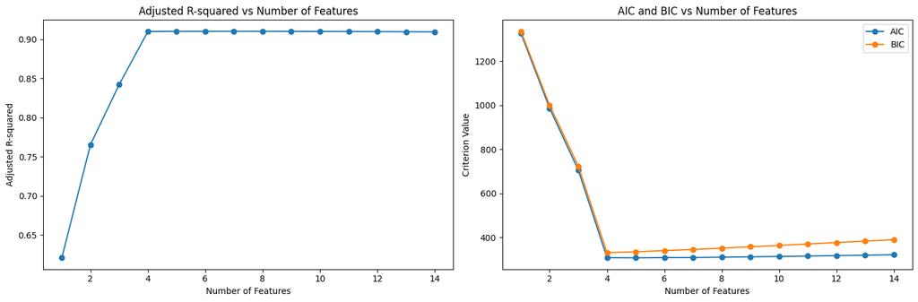

```python
n_features = list(best_models.keys())
adj_r2 = [model['adj_r2'] for model in best_models.values()]
aic = [model['aic'] for model in best_models.values()]
bic = [model['bic'] for model in best_models.values()]

fig, (ax1, ax2) = plt.subplots(1, 2, figsize=(15, 5))

# Plot Adjusted R-squared
ax1.plot(n_features, adj_r2, marker='o')
ax1.set_xlabel('Number of Features')
ax1.set_ylabel('Adjusted R-squared')
ax1.set_title('Adjusted R-squared vs Number of Features')

# Plot AIC and BIC
ax2.plot(n_features, aic, marker='o', label='AIC')
ax2.plot(n_features, bic, marker='o', label='BIC')
ax2.set_xlabel('Number of Features')
ax2.set_ylabel('Criterion Value')
ax2.set_title('AIC and BIC vs Number of Features')
ax2.legend()

plt.tight_layout()
plt.show()
```

**Best Model chosen based on BIC**

BIC penalizes model complexity more heavily than AIC, often leading to more parsimonious models.

```python
# Best model chosen based on BIC
best_bic = float('inf')
best_model_key = None

for k, model_info in best_models.items():
    if model_info['bic'] < best_bic:
        best_bic = model_info['bic']
        best_model_key = k

best_model_info = best_models[best_model_key]
best_model = best_model_info['model']
selected_features = best_model_info['features']

print("\n=== Best Model based on BIC ===")
print(f"Number of features: {best_model_key}")
print(f"Selected features: {selected_features}")
print(f"Adjusted R²: {best_model_info['adj_r2']:.4f}")
print(f"AIC: {best_model_info['aic']:.4f}")
print(f"BIC: {best_model_info['bic']:.4f}")

# Testing the model performance
X_test_subset = X_test[selected_features]  #select the same features
X_test_subset = sm.add_constant(X_test_subset)  # add intercept
y_pred = best_model.predict(X_test_subset)

# Compute performance on test set
mse = mean_squared_error(y_test, y_pred)
rmse = np.sqrt(mse)
r2 = r2_score(y_test, y_pred)

print("\n=== Performance on Test Set ===")
print(f"Mean Squared Error: {mse:.4f}")
#print(f"Root Mean Squared Error: {rmse:.4f}")
print(f"R-squared: {r2:.4f}")

# print coefficients
coef_df = pd.DataFrame({
    'Feature': ['Intercept'] + selected_features,
    'Coefficient': best_model.params.values
})

# order coefficients
#coef_df = coef_df.sort_values(by='Coefficient', ascending=False)

print("\n=== Coefficienti of best model based on BIC  ===")
print(coef_df)
```

```
=== Best Model based on BIC ===
Number of features: 4
Selected features: ['Trip_Distance_km', 'Per_Km_Rate', 'Per_Minute_Rate', 'Trip_Duration_Minutes']
Adjusted R²: 0.9099
AIC: 307.7991
BIC: 330.6395

=== Performance on Test Set ===
Mean Squared Error: 0.1044
R-squared: 0.8987

=== Coefficienti of best model based on BIC  ===
                 Feature  Coefficient
0              Intercept    -0.003232
1       Trip_Distance_km     0.801304
2            Per_Km_Rate     0.362462
3        Per_Minute_Rate     0.255216
4  Trip_Duration_Minutes     0.279656
```

**Best Model chosen based on Adjusted R-squared**

```python
#Find the best model based on Adjusted R²
best_model_key = max(best_models, key=lambda k: best_models[k]['adj_r2'])
best_model_info = best_models[best_model_key]
best_model = best_model_info['model']
selected_features = best_model_info['features']

print("\n=== Best model based on Adjusted R2 ===")
print(f"Number of features: {best_model_key}")
print(f"Selected features: {selected_features}")
print(f"Adjusted R²: {best_model_info['adj_r2']:.4f}")
print(f"AIC: {best_model_info['aic']:.4f}")
print(f"BIC: {best_model_info['bic']:.4f}")

# Testing the model
X_test_subset = X_test[selected_features]  # Seleziona le stesse feature nel test set
X_test_subset = sm.add_constant(X_test_subset)  # Aggiunge l'intercetta
y_pred = best_model.predict(X_test_subset)

# Compute performance
mse = mean_squared_error(y_test, y_pred)
rmse = np.sqrt(mse)
r2 = r2_score(y_test, y_pred)

print("\n=== Performance on Test Set ===")
print(f"Mean Squared Error: {mse:.4f}")
#print(f"Root Mean Squared Error: {rmse:.4f}")
print(f"R-squared: {r2:.4f}")

#Print coefficients
coef_df = pd.DataFrame({
    'Feature': ['Intercept'] + selected_features,
    'Coefficient': best_model.params.values
})

# Ordina i coefficienti in ordine decrescente (opzionale)
#coef_df = coef_df.sort_values(by='Coefficient', ascending=True)

print("\n=== Coefficienti del Modello Migliore ===")
print(coef_df)
```

```
=== Best model based on Adjusted R2 ===
Number of features: 7
Selected features: ['Trip_Distance_km', 'Base_Fare', 'Per_Km_Rate', 'Per_Minute_Rate', 'Trip_Duration_Minutes', 'Time_of_Day_Evening', 'Time_of_Day_Morning']
Adjusted R²: 0.9102
AIC: 308.3595
BIC: 344.9042

=== Performance on Test Set ===
Mean Squared Error: 0.1057
R-squared: 0.8974

=== Coefficienti del Modello Migliore ===
                 Feature  Coefficient
0              Intercept    -0.021899
1       Trip_Distance_km     0.801871
2              Base_Fare     0.019365
3            Per_Km_Rate     0.361959
4        Per_Minute_Rate     0.256894
5  Trip_Duration_Minutes     0.279716
6    Time_of_Day_Evening     0.037822
7    Time_of_Day_Morning     0.036118
```

# Section 8: Destandardization of Coefficients

```python
# Split tha data (not standardized data) (only for unstandardize coefficients)
X = df_linear_model.drop('Trip_Price', axis=1)
y = df_linear_model['Trip_Price']

X_train_un, X_test_un, y_train_un, y_test_un = train_test_split(X, y, test_size=0.2, random_state=42)
```

```python
# Assuming X_train_un is your original (non-standardized) design matrix
# and X_train is the standardized design matrix used in the model

# Get the original column names (excluding any dummy variables)
original_columns = [col for col in X_train_un.columns if col in selected_features and col in numerical_columns]
original_columns
```

```
['Trip_Distance_km',
 'Base_Fare',
 'Per_Km_Rate',
 'Per_Minute_Rate',
 'Trip_Duration_Minutes']
```

```python
# Get standard deviations of original numerical columns
std_X = X_train_un[original_columns].std()
std_X
```

```
Trip_Distance_km         19.979036
Base_Fare                 0.847739
Per_Km_Rate               0.429481
Per_Minute_Rate           0.127030
Trip_Duration_Minutes    31.973500
dtype: float64
```

```python
# Get standardized coefficients (excluding intercept)
beta_standardized = coef_df['Coefficient'][coef_df['Feature'].isin(original_columns)]
beta_standardized
```

```
1    0.801871
2    0.019365
3    0.361959
4    0.256894
5    0.279716
Name: Coefficient, dtype: float64
```

```python
# Index must be coherent with column names
beta_standardized.index = original_columns

# Ora std_X e beta_standardized hanno gli stessi indici
std_X = std_X.loc[beta_standardized.index]
```

```python
# Rescale coefficients
beta_original = beta_standardized * (std_X / np.std(y_train_un))
beta_original
```

```
Trip_Distance_km         0.503311
Base_Fare                0.000516
Per_Km_Rate              0.004884
Per_Minute_Rate          0.001025
Trip_Duration_Minutes    0.280973
dtype: float64
```

```python
[best_model.params[0]] + list(beta_original) + [best_model.params[6]] + [best_model.params[7]]
```

```
[np.float64(-0.021898931988274903),
 0.5033113870109599,
 0.0005157357818205031,
 0.004883832329424556,
 0.0010252266664829651,
 0.28097347804410855,
 np.float64(0.037822015562419375),
 np.float64(0.036117714863607056)]
```

```python
# Reconstruct with intercept
beta_original_with_intercept = pd.Series(
    [best_model.params[0]] + list(beta_original) + [best_model.params[6]] + [best_model.params[7]],
    index=['Intercept'] + list(original_columns) + ['Time_of_Day_Evening'] + ['Time_of_Day_Morning']
)

print(beta_original_with_intercept)
```

```
Intercept               -0.021899
Trip_Distance_km         0.503311
Base_Fare                0.000516
Per_Km_Rate              0.004884
Per_Minute_Rate          0.001025
Trip_Duration_Minutes    0.280973
Time_of_Day_Evening      0.037822
Time_of_Day_Morning      0.036118
dtype: float64
```

# Section 9: Elastic Net Regression

```python
df_model_scaled.info()
```

```
<class 'pandas.core.frame.DataFrame'>
RangeIndex: 891 entries, 0 to 890
Data columns (total 15 columns):
 #   Column                     Non-Null Count  Dtype
---  ------                     --------------  -----
 0   Trip_Distance_km           891 non-null    float64
 1   Passenger_Count            891 non-null    float64
 2   Base_Fare                  891 non-null    float64
 3   Per_Km_Rate                891 non-null    float64
 4   Per_Minute_Rate            891 non-null    float64
 5   Trip_Duration_Minutes      891 non-null    float64
 6   Trip_Price                 891 non-null    float64
 7   Time_of_Day_Evening        891 non-null    bool
 8   Time_of_Day_Morning        891 non-null    bool
 9   Time_of_Day_Night          891 non-null    bool
 10  Day_of_Week_Weekend        891 non-null    bool
 11  Traffic_Conditions_Low     891 non-null    bool
 12  Traffic_Conditions_Medium  891 non-null    bool
 13  Weather_Rain               891 non-null    bool
 14  Weather_Snow               891 non-null    bool
dtypes: bool(8), float64(7)
memory usage: 55.8 KB
```

```python
X = df_model_scaled.drop('Trip_Price', axis=1)
y = df_model_scaled['Trip_Price']

# Transform booleans in integer for better handling
bool_columns = X.select_dtypes(include='bool').columns
X[bool_columns] = X[bool_columns].astype(int)

# Split the  dataset (80% training, 20% test)
X_train, X_test, y_train, y_test = train_test_split(X, y, test_size=0.2, random_state=42)
```

**Elastic net with parameters found by cross-validation**

```python
from sklearn.linear_model import ElasticNetCV

# Create and train the ElasticNetCV model with cross-validation
elastic_net_cv = ElasticNetCV(cv=5, random_state=42)  # cv=5 for 5-fold cross-validation
elastic_net_cv.fit(X_train, y_train)

# Coefficients of the final model
intercept = elastic_net_cv.intercept_
coefficients = elastic_net_cv.coef_

# Create a DataFrame to display the coefficients
coeff_df = pd.DataFrame({
    'Feature': X.columns,
    'Coefficient': coefficients
})

# Sort the coefficients in descending order (optional)
#coeff_df = coeff_df.sort_values(by='Coefficient', ascending=False)

# # Print the results of the model
print("\n=== ElasticNet Model Summary ===")
print(f"Best alpha: {elastic_net_cv.alpha_}")
print(f"Best L1 Ratio (Mix Lasso-Ridge): {elastic_net_cv.l1_ratio_}")
print(f"Intercept (β0): {elastic_net_cv.intercept_:.4f}\n")
print("Feature Coefficients:")
print(coeff_df)

# Make predictions on the test set
y_pred = elastic_net_cv.predict(X_test)
mse = mean_squared_error(y_test, y_pred)
rmse = np.sqrt(mse)
r2 = r2_score(y_test, y_pred)

# Make predictions on the test set
y_pred = elastic_net_cv.predict(X_test)

# Calculate performance metrics
mse = mean_squared_error(y_test, y_pred)
rmse = mse**0.5
r2 = r2_score(y_test, y_pred)

print("\nModel Performance Metrics:")
print(f"Mean Squared Error(test): {mse:.4f}")
#print(f"Root Mean Squared Error: {rmse:.4f}")
print(f"R-squared: {r2:.4f}")
```

```
=== ElasticNet Model Summary ===
Best alpha: 0.011016263283795152
Best L1 Ratio (Mix Lasso-Ridge): 0.5
Intercept (β0): -0.0031

Feature Coefficients:
                      Feature  Coefficient
0            Trip_Distance_km     0.790599
1             Passenger_Count     0.001986
2                   Base_Fare     0.012914
3                 Per_Km_Rate     0.355051
4             Per_Minute_Rate     0.249703
5       Trip_Duration_Minutes     0.272150
6         Time_of_Day_Evening     0.000000
7         Time_of_Day_Morning     0.000000
8           Time_of_Day_Night    -0.000000
9         Day_of_Week_Weekend     0.000000
10     Traffic_Conditions_Low     0.000000
11  Traffic_Conditions_Medium    -0.000000
12               Weather_Rain     0.000000
13               Weather_Snow     0.000000

Model Performance Metrics:
Mean Squared Error(test): 0.1048
R-squared: 0.8983
```

# Section 10: Linear Regression with Interaction Terms

```python
df_model_scaled.info()
```

```
<class 'pandas.core.frame.DataFrame'>
RangeIndex: 891 entries, 0 to 890
Data columns (total 15 columns):
 #   Column                     Non-Null Count  Dtype
---  ------                     --------------  -----
 0   Trip_Distance_km           891 non-null    float64
 1   Passenger_Count            891 non-null    float64
 2   Base_Fare                  891 non-null    float64
 3   Per_Km_Rate                891 non-null    float64
 4   Per_Minute_Rate            891 non-null    float64
 5   Trip_Duration_Minutes      891 non-null    float64
 6   Trip_Price                 891 non-null    float64
 7   Time_of_Day_Evening        891 non-null    bool
 8   Time_of_Day_Morning        891 non-null    bool
 9   Time_of_Day_Night          891 non-null    bool
 10  Day_of_Week_Weekend        891 non-null    bool
 11  Traffic_Conditions_Low     891 non-null    bool
 12  Traffic_Conditions_Medium  891 non-null    bool
 13  Weather_Rain               891 non-null    bool
 14  Weather_Snow               891 non-null    bool
dtypes: bool(8), float64(7)
memory usage: 55.8 KB
```

```python
#creation of interaction terms
df_model_scaled['Distance_Weekend_Interaction'] = df_model_scaled['Trip_Distance_km'] * df_model_scaled['Day_of_Week_Weekend']
df_model_scaled['KmRate_TrafficMedium_Interaction'] = df_model_scaled['Per_Km_Rate'] * df_model_scaled['Traffic_Conditions_Medium']
df_model_scaled['KmRate_TrafficLow_Interaction'] = df_model_scaled['Per_Km_Rate'] * df_model_scaled['Traffic_Conditions_Low']
df_model_scaled['Duration_Snow_Interaction'] = df_model_scaled['Trip_Duration_Minutes'] * df_model_scaled['Weather_Snow']
df_model_scaled['Duration_Rain_Interaction'] = df_model_scaled['Trip_Duration_Minutes'] * df_model_scaled['Weather_Rain']


df_model_scaled
```

|  | Trip_Distance_km | Passenger_Count | Base_Fare | Per_Km_Rate | Per_Minute_Rate | Trip_Duration_Minutes | Trip_Price | Time_of_Day_Evening | Time_of_Day_Morning | Time_of_Day_Night | Day_of_Week_Weekend | Traffic_Conditions_Low | Traffic_Conditions_Medium | Weather_Rain | Weather_Snow | Distance_Weekend_Interaction | KmRate_TrafficMedium_Interaction | KmRate_TrafficLow_Interaction | Duration_Snow_Interaction | Duration_Rain_Interaction |
| --- | --- | --- | --- | --- | --- | --- | --- | --- | --- | --- | --- | --- | --- | --- | --- | --- | --- | --- | --- | --- |
| 0 | -0.388302 | 0.462410 | 0.061326 | -1.008027 | 0.207097 | -0.255712 | -0.591457 | False | True | False | False | True | False | False | False | -0.000000 | -0.000000 | -1.008027 | -0.0 | -0.000000 |
| 1 | 0.484168 | -1.393478 | -0.948185 | -0.060467 | -1.153985 | -0.770279 | -0.070662 | True | False | False | True | False | False | False | False | 0.484168 | -0.000000 | -0.000000 | -0.0 | -0.000000 |
| 2 | 0.158486 | 1.390353 | -0.032582 | -1.678253 | -1.153985 | 1.702748 | -0.584966 | True | False | False | False | True | False | False | False | 0.000000 | -0.000000 | -1.678253 | 0.0 | 0.000000 |
| 3 | -0.921645 | -0.465534 | -1.124262 | 1.095093 | 1.488116 | 0.848351 | 0.157787 | False | False | False | True | False | True | False | False | -0.921645 | 1.095093 | 0.000000 | 0.0 | 0.000000 |
| 4 | -1.160180 | 1.390353 | 0.002633 | 0.979537 | -0.193221 | -1.772050 | -1.373796 | False | False | False | False | False | False | True | False | -0.000000 | 0.000000 | 0.000000 | -0.0 | -1.772050 |
| ... | ... | ... | ... | ... | ... | ... | ... | ... | ... | ... | ... | ... | ... | ... | ... | ... | ... | ... | ... | ... |
| 886 | -1.078510 | 1.390353 | -1.312078 | -1.424029 | 1.568180 | -0.113624 | -0.649589 | False | False | False | True | False | True | False | False | -1.078510 | -1.424029 | -0.000000 | -0.0 | -0.000000 |
| 887 | 0.936339 | 1.390353 | -0.455168 | -1.447140 | 1.648243 | -0.002627 | 0.218086 | False | False | True | False | False | True | False | False | 0.000000 | -1.447140 | -0.000000 | -0.0 | -0.000000 |
| 888 | -0.968455 | 0.462410 | -1.675972 | 1.256872 | 0.207097 | -0.244519 | -0.689689 | False | True | False | False | True | False | True | False | -0.000000 | 0.000000 | 1.256872 | -0.0 | -0.244519 |
| 889 | 1.016515 | -1.393478 | -0.983400 | -0.961805 | -0.993858 | 1.644607 | 0.189278 | False | True | False | False | True | False | False | False | 0.000000 | -0.000000 | -0.961805 | 0.0 | 0.000000 |
| 890 | -0.214007 | 0.462410 | 0.976928 | 0.609758 | -0.513476 | -1.005953 | -0.304117 | False | True | False | True | False | True | False | False | -0.214007 | 0.609758 | 0.000000 | -0.0 | -0.000000 |

891 rows × 20 columns

```python
#drop the dummies to avoid replicating the same information
columns_to_drop = ['Day_of_Week_Weekend', 'Traffic_Conditions_Low', 'Traffic_Conditions_Medium','Weather_Rain','Weather_Snow']
df_model_scaled = df_model_scaled.drop(columns_to_drop, axis = 1)
```

```python
# split the variables into predictors X (features) e y (target)
X = df_model_scaled.drop('Trip_Price', axis=1)
y = df_model_scaled['Trip_Price']

# Transform booleans in integer for better handling
bool_columns = X.select_dtypes(include='bool').columns
X[bool_columns] = X[bool_columns].astype(int)

# Split dataset into training and test (80% training, 20% test)
X_train, X_test, y_train, y_test = train_test_split(X, y, test_size=0.2, random_state=42)

# Add constant for statsmodels
X_train_sm = sm.add_constant(X_train)
X_train_sm = X_train_sm.reset_index(drop=True)
y_train = y_train.reset_index(drop=True)

# Fit the model
linear_model = sm.OLS(y_train, X_train_sm).fit()

# Print summary
print("\nModel Summary:")
print(linear_model.summary())
```

```
Model Summary:
                            OLS Regression Results
==============================================================================
Dep. Variable:             Trip_Price   R-squared:                       0.912
Model:                            OLS   Adj. R-squared:                  0.910
Method:                 Least Squares   F-statistic:                     516.8
Date:                Wed, 21 May 2025   Prob (F-statistic):               0.00
Time:                        01:30:00   Log-Likelihood:                -141.81
No. Observations:                 712   AIC:                             313.6
Df Residuals:                     697   BIC:                             382.1
Df Model:                          14
Covariance Type:            nonrobust
====================================================================================================
                                       coef    std err          t      P>|t|      [0.025      0.975]
----------------------------------------------------------------------------------------------------
const                               -0.0186      0.018     -1.042      0.298      -0.054       0.016
Trip_Distance_km                     0.7959      0.013     59.271      0.000       0.770       0.822
Passenger_Count                      0.0064      0.011      0.568      0.571      -0.016       0.028
Base_Fare                            0.0180      0.011      1.587      0.113      -0.004       0.040
Per_Km_Rate                          0.4259      0.027     15.904      0.000       0.373       0.479
Per_Minute_Rate                      0.2583      0.011     23.271      0.000       0.237       0.280
Trip_Duration_Minutes                0.2792      0.014     20.539      0.000       0.252       0.306
Time_of_Day_Evening                  0.0320      0.030      1.063      0.288      -0.027       0.091
Time_of_Day_Morning                  0.0343      0.028      1.244      0.214      -0.020       0.088
Time_of_Day_Night                   -0.0117      0.040     -0.290      0.772      -0.091       0.068
Distance_Weekend_Interaction         0.0223      0.025      0.895      0.371      -0.027       0.071
KmRate_TrafficMedium_Interaction    -0.0827      0.032     -2.553      0.011      -0.146      -0.019
KmRate_TrafficLow_Interaction       -0.0749      0.032     -2.359      0.019      -0.137      -0.013
Duration_Snow_Interaction            0.0320      0.054      0.591      0.555      -0.074       0.138
Duration_Rain_Interaction           -0.0051      0.026     -0.191      0.848      -0.057       0.047
==============================================================================
Omnibus:                      158.658   Durbin-Watson:                   2.013
Prob(Omnibus):                  0.000   Jarque-Bera (JB):             5232.741
Skew:                           0.032   Prob(JB):                         0.00
Kurtosis:                      16.281   Cond. No.                         5.75
==============================================================================

Notes:
[1] Standard Errors assume that the covariance matrix of the errors is correctly specified.
```

# Interpretation of the Interaction Terms

### 1. **KmRate_TrafficLow_Interaction**

*Relative to the baseline: `Traffic_Conditions_High`*

- `Traffic_Conditions_Low = 1` indicates low traffic conditions (compared to high).
- The coefficient for `KmRate_TrafficLow_Interaction` is **β = -0.0749**, representing the change in the effect of `Per_Km_Rate` when moving from high to low traffic.

**Effect Breakdown:**

- **High traffic (baseline):** Effect of `Per_Km_Rate` = **0.4259**
- **Low traffic:** Effect = **0.4259 - 0.0749 = 0.351**

This means the impact of the per-km rate on price is **lower in low traffic conditions**. In other words, under light traffic, the effect of distance pricing is significantly reduced—possibly reflecting **greater operational efficiency** and a **pricing strategy** designed to pass savings on to the customer.

### 2. **KmRate_TrafficMedium_Interaction**

*Relative to the baseline: `Traffic_Conditions_High`*

- `Traffic_Conditions_Medium = 1` indicates medium traffic conditions (compared to high).
- The coefficient for `KmRate_TrafficMedium_Interaction` is **β = -0.0827**, representing the change in the effect of `Per_Km_Rate` when moving from high to medium traffic.

**Effect Breakdown:**

- **High traffic (baseline):** Effect = **0.4259**
- **Medium traffic:** Effect = **0.4259 - 0.0827 = 0.3432**

This implies a **reduced effect of the per-km rate** under medium traffic. Like the case for low traffic, this may reflect **efficiency gains** or an intentional **price adjustment** for varying traffic conditions.

### 3. **Distance_Weekend_Interaction**

*Relative to the baseline: `Day_of_Week_Weekday`*

- Main variable `Trip_Distance_km` has coefficient **β = 0.7959**
- `Weekend = 1` represents weekend trips.
- The interaction coefficient is **β = 0.0223**, representing the change in the effect of distance on weekends.

**Effect Breakdown:**

- **Weekdays (baseline):** Effect = **0.7959**
- **Weekends:** Effect = **0.7959 + 0.0223 = 0.8182**

This suggests a **higher price sensitivity to distance on weekends**. It could reflect a *pricing policy* that increases the influence of distance during weekends—possibly to compensate for **increased demand**, **driver availability issues**, or **greater value placed on convenience**.

### 4. **Duration_Rain_Interaction**

*Relative to the baseline: `Weather_Sun`*

- Main variable `Trip_Duration_Minutes` has coefficient **β = 0.2792**
- `Weather_Rain = 1` indicates rainy conditions.
- The interaction coefficient is **β = -0.0051**

**Effect Breakdown:**

- **Sunny weather (baseline):** Effect = **0.2792**
- **Rainy weather:** Effect = **0.2792 - 0.0051 = 0.2741**

The **slightly lower impact** of trip duration on price in rainy weather suggests that **service providers might absorb some of the additional costs** caused by adverse weather to **keep prices customer-friendly**. This may be part of a **customer retention strategy**—ensuring price increases due to external conditions (like rain) don't deter usage.

### 5. **Duration_Snow_Interaction**

*Relative to the baseline: `Weather_Sun`*

- Main variable `Trip_Duration_Minutes` has coefficient **β = 0.2792**
- `Weather_Snow = 1` indicates snowy conditions.
- The interaction coefficient is **β = 0.0320**

**Effect Breakdown:**

- **Sunny weather (baseline):** Effect = **0.2792**
- **Snowy weather:** Effect = **0.2792 + 0.0320 = 0.3112**

In contrast to rain, snowy conditions **increase** the effect of trip duration on pricing. This reflects the **higher operational costs** and **longer trip times** due to poor road conditions. It may also relate to **supply-demand dynamics**—with higher demand and fewer available drivers in snowy weather pushing prices upward. Moreover, platforms may offer **driver compensation bonuses**, which are then passed to customers via fare adjustments.

```python
# Add constant for prediction
X_test_sm = sm.add_constant(X_test)

# Make predictions
y_pred = linear_model.predict(X_test_sm)

# Calculate metrics
mse = np.mean((y_test - y_pred) ** 2)
rmse = np.sqrt(mse)
r2 = linear_model.rsquared

# Calculate metrics on actual price scale
actual_prices = np.exp(y_test)
predicted_prices = np.exp(y_pred)
mape = np.mean(np.abs((actual_prices - predicted_prices) / actual_prices)) * 100

print("\nModel Performance Metrics:")
print(f"Mean Squared Error(test): {mse:.4f}")
#print(f"Root Mean Squared Error: {rmse:.4f}")
print(f"R-squared: {r2:.4f}")
#print(f"Mean Absolute Percentage Error: {mape:.2f}%")
```

```
Model Performance Metrics:
Mean Squared Error(test): 0.1076
R-squared: 0.9121
```